# ADS 503 Team 4: Predicting Article Shares

# Load Data

```r
df <- read.csv("Datasets/OnlineNewsPopularity.csv")
dim(df)
```

```
[1] 39644    61
```

The dataset has 39,644 samples and 61 variables.

# Missing Data

```r
na.by.col <- apply(df, 2, function(x) sum(is.na(x)))
any(na.by.col > 0)
```

```
[1] FALSE
```

None of the variables are missing any data.

# Define Target and Predictors

```r
df <- df[, names(df) != "url"] # drop the url column, which functions as a sample ID
y <- df$shares  # shares is the target variable
X <- df[, names(df) != "shares"]
```

# Target Distribution

```r
summary(y)
```

```
   Min. 1st Qu.  Median    Mean 3rd Qu.    Max.
      1     946    1400    3395    2800  843300
```

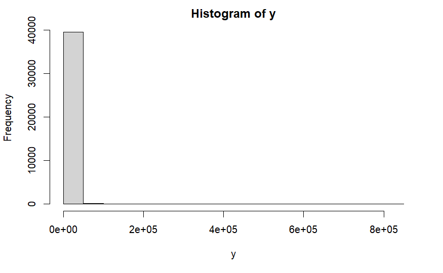

```r
hist(y)
```

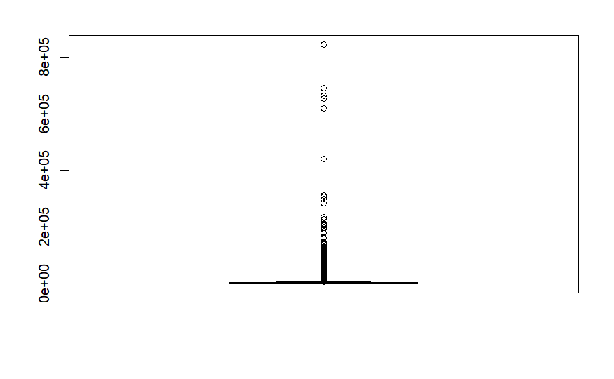

```r
boxplot(y)
```

The target distribution is highly right-skewed. Let’s try log transforming it.

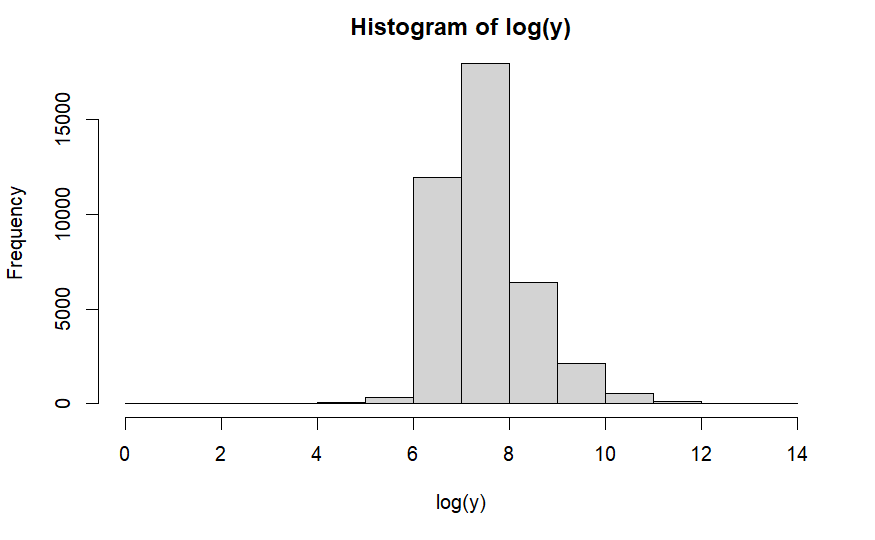

```r
hist(log(y))
```

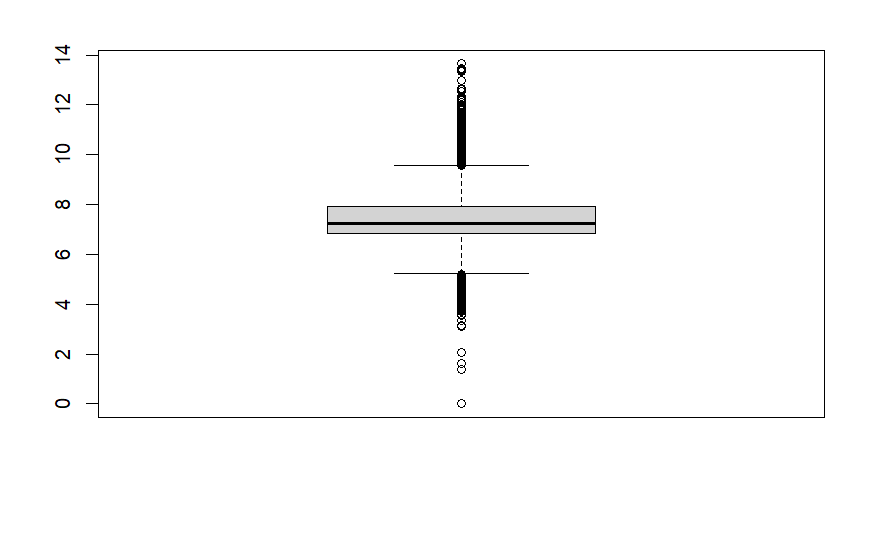

```r
boxplot(log(y))
```

The log of the target is much less skewed. Let’s apply the log transformation.

```r
y <- log(y)
```

# Binary Predictors

```r
unique(apply(X, 2, typeof)) # check predictor data types
```

```
[1] "double"
```

```r
is.binary <- function(x) { # function to check whether or not a variable is binary
  n.unique <- length(unique(x))
  min <- min(x)
  max <- max(x)
  if (n.unique == 2 & min == 0 & max == 1) {
    return(TRUE)
  }
  else {
    return(FALSE)
  }
}

binary.cols <- names(X)[apply(X, 2, is.binary)]
X.binary <- X[, binary.cols]
X.non.binary <- X[, !names(X) %in% binary.cols]
binary.cols
```

```
 [1] "data_channel_is_lifestyle"     "data_channel_is_entertainment" "data_channel_is_bus"           "data_channel_is_socmed"        "data_channel_is_tech"
 [6] "data_channel_is_world"         "weekday_is_monday"             "weekday_is_tuesday"            "weekday_is_wednesday"          "weekday_is_thursday"
[11] "weekday_is_friday"             "weekday_is_saturday"           "weekday_is_sunday"             "is_weekend"
```

All predictors are of data type double. 14 of them are binary variables.

# Near-Zero Variance Predictors

```r
library(caret)
zero.var.cols <- nearZeroVar(X)
names(X)[zero.var.cols]
```

```
[1] "kw_min_max"
```

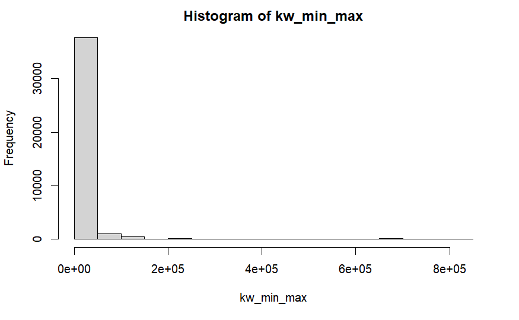

```r
kw_min_max <- X[, "kw_min_max"]
hist(kw_min_max)
```

kw_min_max is the only predictor with near-zero variance. Let’s remove it.

```r
X <- X[, names(X) != "kw_min_max"]
```

# Predictor Correlations

## Non-Binary Predictors

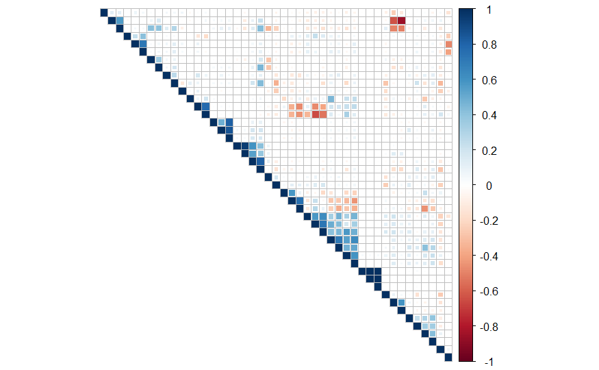

```r
library(corrplot)
cor.matrix <- cor(X.non.binary)
corrplot(
  cor.matrix,
  method = "square",
  type = "upper",
  order = "hclust",
  tl.pos = "n"
)
```

```r
high.cor <- findCorrelation(cor.matrix, cutoff = .7) # variables contributing to high pairwise correlations
length(names(X.non.binary)[high.cor])
```

```
[1] 12
```

There are 12 non-binary predictors contributing to high pairwise correlations. Let’s remove them to avoid multicolinearity issues.

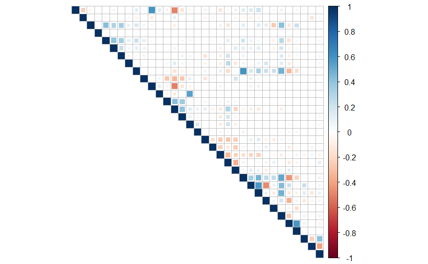

```r
X.non.binary <- X.non.binary[, -high.cor]
cor.matrix.filtered <- cor(X.non.binary)
corrplot(
  cor.matrix.filtered,
  method = "square",
  type = "upper",
  tl.pos = "n"
)
```

## Binary Predictors

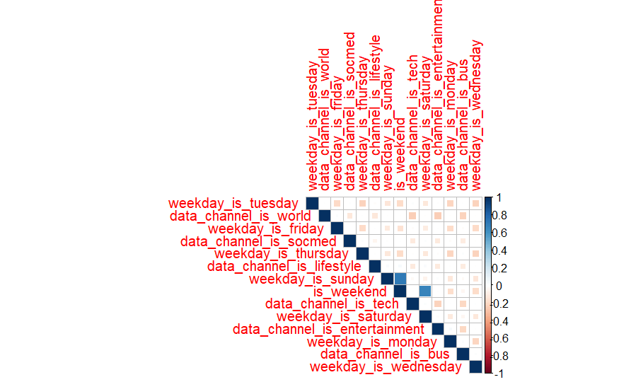

```r
cor.matrix <- cor(X.binary)
corrplot(
  cor.matrix,
  method = "square",
  type = "upper",
  order = "hclust"
)
```

```r
high.cor <- findCorrelation(cor.matrix, cutoff = .7) # variables contributing to high pairwise correlations
names(X.binary)[high.cor]
```

```
[1] "is_weekend"
```

One of the binary predictors contributes to pairwise correlations greater than .70. Furthermore, there is a binary indicator for every day of the week, so we need to remove one to avoid the dummy variable trap.

```r
X.binary <- X.binary[, -high.cor]
X.binary <- X.binary[, names(X.binary) != "weekday_is_sunday"]
```

Let’s also check the channel variables for the dummy trap.

```r
channels <- c(
  "data_channel_is_world",
  "data_channel_is_socmed",
  "data_channel_is_tech",
  "data_channel_is_bus",
  "data_channel_is_entertainment",
  "data_channel_is_lifestyle"
)
summary(apply(X[, channels], 1, sum)) # check if they always sum to 1 for every sample
```

```
   Min. 1st Qu.  Median    Mean 3rd Qu.    Max.
 0.0000  1.0000  1.0000  0.8453  1.0000  1.0000
```

They do not always sum to 1 for every sample, so they do not fall into the dummy variable trap. Let’s update our master predictor matrix to only retain the non-redundant predictors.

```r
cols.to.keep <- c(names(X.non.binary), names(X.binary))
X <- X[, names(X) %in% cols.to.keep]
```

# Split the Data

```r
set.seed(100)
trainingRows <- createDataPartition(y, p = .80,  list = FALSE)
y.train <- y[trainingRows]
y.test <- y[-trainingRows]
X.train <- X[trainingRows, ]
X.test <- X[-trainingRows, ]
idx <- createFolds(y.train, returnTrain = TRUE)
ctrl <- trainControl(method = "cv", index = idx)
```

# Modeling

## CART

```r
cart <- train(
  x = X.train,
  y = y.train,
  trControl = ctrl,
  preProcess = c("center", "scale"),
  method = "rpart",
  tuneGrid = expand.grid(cp = seq(0.001, 0.1, 0.001))
)
cart
```

```
CART

31716 samples
   44 predictor

Pre-processing: centered (44), scaled (44)
Resampling: Cross-Validated (10 fold)
Summary of sample sizes: 28545, 28543, 28544, 28545, 28545, 28543, ...
Resampling results across tuning parameters:

  cp     RMSE       Rsquared    MAE
  0.001  0.8815608  0.10648392  0.6569817
  0.002  0.8869769  0.09497542  0.6624583
  0.003  0.8903170  0.08807854  0.6656331
  0.004  0.8921811  0.08423871  0.6674246
  0.005  0.8967221  0.07486635  0.6728764
  0.006  0.8978037  0.07265777  0.6739963
  0.007  0.8993221  0.06947468  0.6752790
  0.008  0.9023276  0.06326890  0.6791601
  0.009  0.9030281  0.06184649  0.6803080
  0.010  0.9030281  0.06184649  0.6803080
  0.011  0.9030281  0.06184649  0.6803080
  0.012  0.9030281  0.06184649  0.6803080
  0.013  0.9030281  0.06184649  0.6803080
  0.014  0.9030281  0.06184649  0.6803080
  0.015  0.9030281  0.06184649  0.6803080
  0.016  0.9030281  0.06184649  0.6803080
  0.017  0.9030281  0.06184649  0.6803080
  0.018  0.9030281  0.06184649  0.6803080
  0.019  0.9042354  0.05932255  0.6813069
  0.020  0.9103767  0.04637005  0.6865803
  0.021  0.9123928  0.04223782  0.6883649
  0.022  0.9123928  0.04223782  0.6883649
  0.023  0.9123928  0.04223782  0.6883649
  0.024  0.9123928  0.04223782  0.6883649
  0.025  0.9123928  0.04223782  0.6883649
  0.026  0.9123928  0.04223782  0.6883649
  0.027  0.9123928  0.04223782  0.6883649
  0.028  0.9123928  0.04223782  0.6883649
  0.029  0.9123928  0.04223782  0.6883649
```

[output cut: 59 more lines]

```
  0.089  0.9321901         NaN  0.7055694
  0.090  0.9321901         NaN  0.7055694
  0.091  0.9321901         NaN  0.7055694
  0.092  0.9321901         NaN  0.7055694
  0.093  0.9321901         NaN  0.7055694
  0.094  0.9321901         NaN  0.7055694
  0.095  0.9321901         NaN  0.7055694
  0.096  0.9321901         NaN  0.7055694
  0.097  0.9321901         NaN  0.7055694
  0.098  0.9321901         NaN  0.7055694
  0.099  0.9321901         NaN  0.7055694
  0.100  0.9321901         NaN  0.7055694

RMSE was used to select the optimal model using the smallest value.
The final value used for the model was cp = 0.001.
```

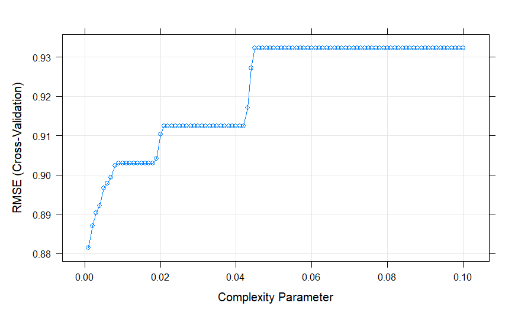

```r
plot(cart)
```

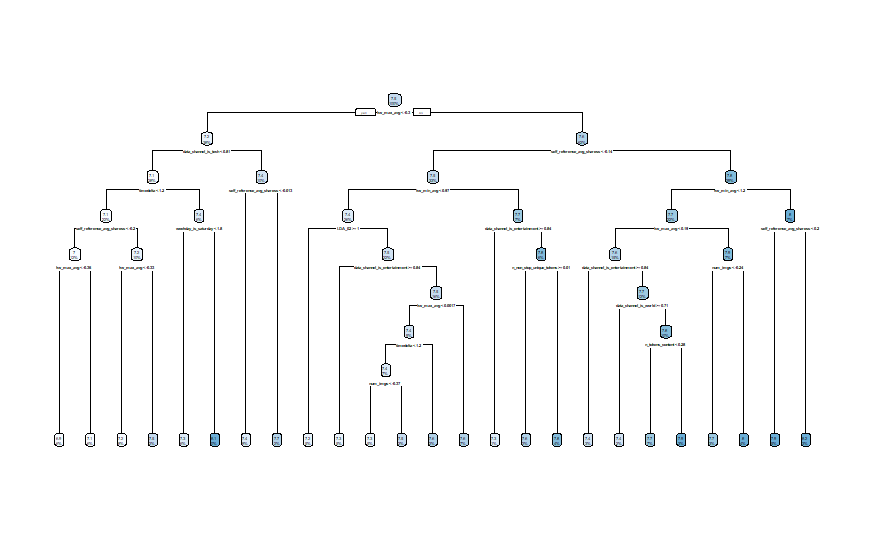

```r
library(rpart.plot)
library(tidyverse)
library(ggplot2)
rpart.plot(cart$finalModel)
```

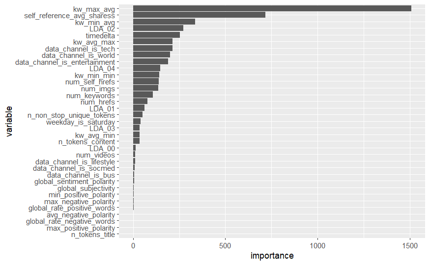

```r
cart.var.imp <- data.frame(importance = cart$finalModel$variable.importance)
cart.var.imp <- cart.var.imp %>%
  tibble::rownames_to_column() %>%
  dplyr::rename("variable" = rowname) %>%
  dplyr::arrange(importance) %>%
  dplyr::mutate(variable = forcats::fct_inorder(variable))
ggplot(cart.var.imp) +
  geom_col(aes(x = variable, y = importance)) +
  coord_flip()
```

```r
library(Metrics)
pred.cart <- predict(cart, X.test)
rmse(y.test, pred.cart)
```

```
[1] 0.8773104
```

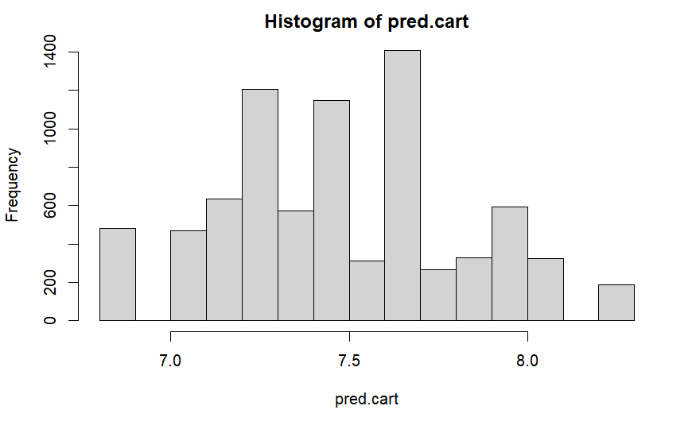

```r
hist(pred.cart)
```

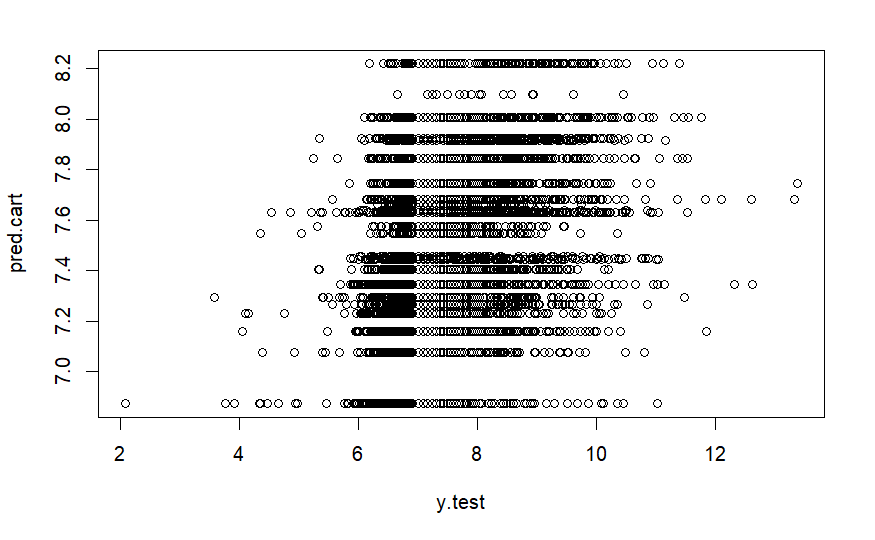

```r
plot(y.test, pred.cart)
```

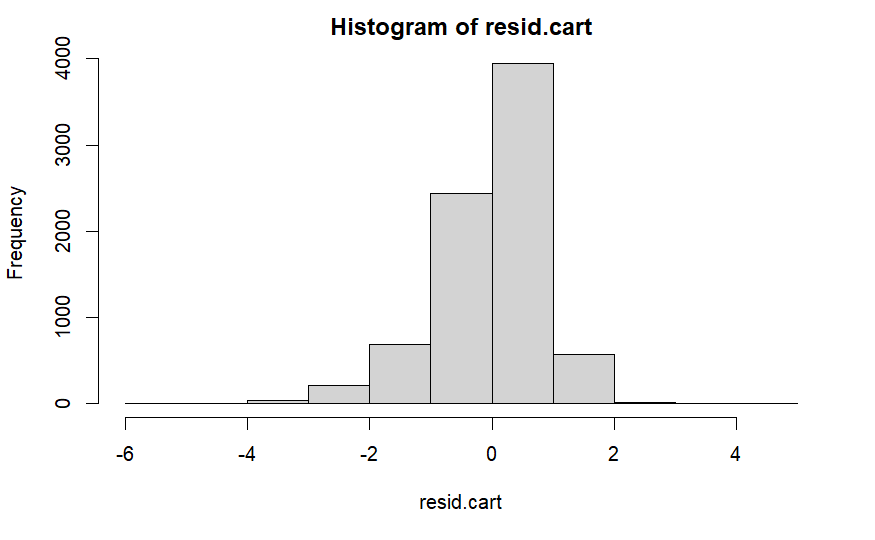

```r
resid.cart <- pred.cart - y.test
hist(resid.cart)
```

## Bagged CART

```r
set.seed(100)
treebag <- train(
  x = X.train,
  y = y.train,
  trControl = ctrl,
  preProcess = c("center", "scale"),
  method = "treebag"
)
treebag
```

```
Bagged CART

31716 samples
   44 predictor

Pre-processing: centered (44), scaled (44)
Resampling: Cross-Validated (10 fold)
Summary of sample sizes: 28545, 28543, 28544, 28545, 28545, 28543, ...
Resampling results:

  RMSE       Rsquared    MAE
  0.9013124  0.06556865  0.678646
```

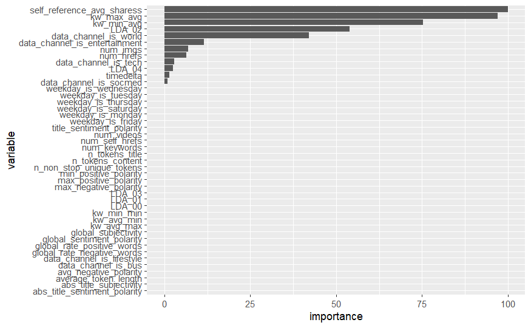

```r
treebag.var.imp <- varImp(treebag)$importance
names(treebag.var.imp) <- "importance"
treebag.var.imp <- treebag.var.imp %>%
  tibble::rownames_to_column() %>%
  dplyr::rename("variable" = rowname) %>%
  dplyr::arrange(importance) %>%
  dplyr::mutate(variable = forcats::fct_inorder(variable))
ggplot(treebag.var.imp) +
  geom_col(aes(x = variable, y = importance)) +
  coord_flip()
```

```r
pred.treebag <- predict(treebag, X.test)
rmse(y.test, pred.treebag)
```

```
[1] 0.8932631
```

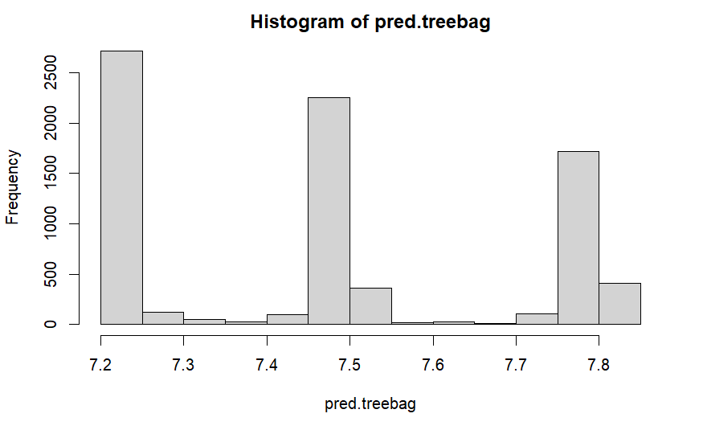

```r
hist(pred.treebag)
```

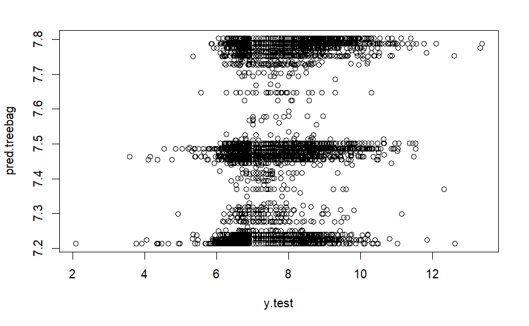

```r
plot(y.test, pred.treebag)
```

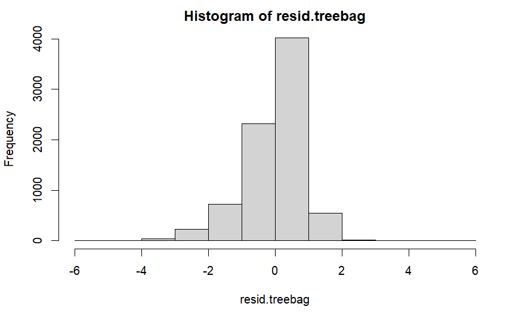

```r
resid.treebag <- pred.treebag - y.test
hist(resid.treebag)
```

## Stochastic Gradient Boosting

```r
gbm.grid <- expand.grid(n.trees = 100, interaction.depth = 1:5, shrinkage = c(0.01, 0.1), n.minobsinnode = 10)
set.seed(100)
gbm <- train(
  x = X.train,
  y = y.train,
  trControl = ctrl,
  preProcess = c("center", "scale"),
  method = "gbm",
  tuneGrid = gbm.grid
)
gbm
```

```
Stochastic Gradient Boosting

31716 samples
   44 predictor

Pre-processing: centered (44), scaled (44)
Resampling: Cross-Validated (10 fold)
Summary of sample sizes: 28545, 28543, 28544, 28545, 28545, 28543, ...
Resampling results across tuning parameters:

  shrinkage  interaction.depth  RMSE       Rsquared    MAE
  0.01       1                  0.9083963  0.08445183  0.6855248
  0.01       2                  0.9012932  0.09478318  0.6790713
  0.01       3                  0.8966554  0.10567896  0.6742977
  0.01       4                  0.8936561  0.11116160  0.6713627
  0.01       5                  0.8914927  0.11522411  0.6690840
  0.10       1                  0.8726627  0.12823473  0.6497059
  0.10       2                  0.8651327  0.14071612  0.6416147
  0.10       3                  0.8608702  0.14864414  0.6381675
  0.10       4                  0.8586408  0.15283182  0.6358339
  0.10       5                  0.8573851  0.15501048  0.6346975

Tuning parameter 'n.trees' was held constant at a value of 100
Tuning parameter 'n.minobsinnode' was held constant at a value of 10
RMSE was used to select the optimal model using the smallest value.
The final values used for the model were n.trees = 100, interaction.depth = 5, shrinkage = 0.1 and n.minobsinnode = 10.
```

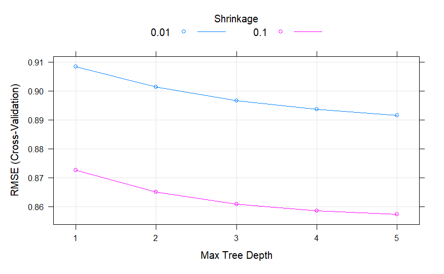

```r
plot(gbm)
```

[output not shown]

[output cut: 34 more lines]

[figure not shown]

```r
pred.gbm <- predict(gbm, X.test)
rmse(y.test, pred.gbm)
```

```
[1] 0.8479553
```

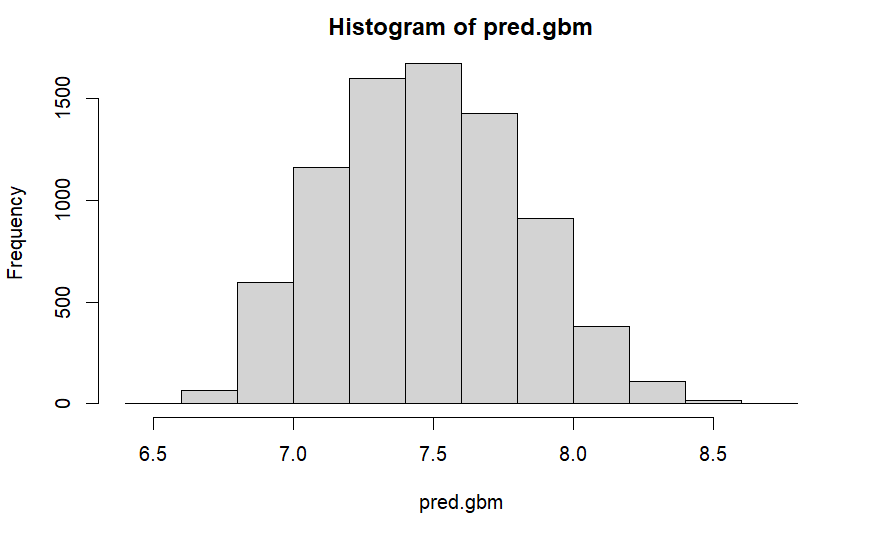

```r
hist(pred.gbm)
```

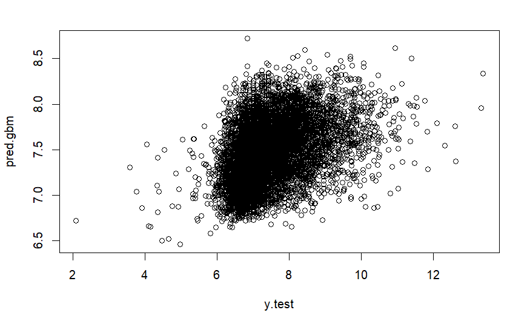

```r
plot(y.test, pred.gbm)
```

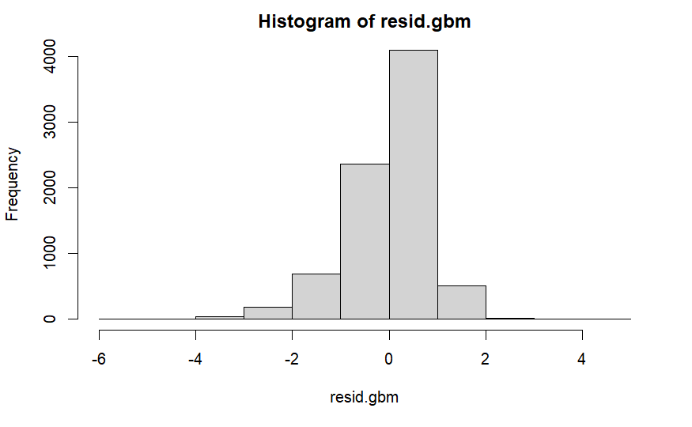

```r
resid.gbm <- pred.gbm - y.test
hist(resid.gbm)
```